# Brain Tumor Classifier MRI

```python
!pip install visualkeras
```

```
Downloading visualkeras-0.1.4-py3-none-any.whl (17 kB)
Downloading aggdraw-1.3.19-cp312-cp312-manylinux_2_17_x86_64.manylinux2014_x86_64.whl (1.0 MB)
   ━━━━━━━━━━━━━━━━━━━━━━━━━━━━━━━━━━━━━━━━ 1.0/1.0 MB 25.7 MB/s eta 0:00:00
```

## Libraries and setup

```python
import kagglehub
import tensorflow as tf
from tensorflow.keras import mixed_precision
from tensorflow.keras.preprocessing.image import ImageDataGenerator
import matplotlib.pyplot as plt

from tensorflow.keras.applications import EfficientNetV2B0, Xception
from tensorflow.keras.layers import (Input, Dense, GlobalAveragePooling2D, Dropout,
                                     Flatten, Conv2D, MaxPooling2D, BatchNormalization)
from tensorflow.keras.models import Model
from tensorflow.keras.metrics import Precision, Recall

from sklearn.metrics import classification_report, confusion_matrix
import seaborn as sns
import numpy as np

from visualkeras import layered_view
```

```python
# Check if GPU is available
print("Num GPUs Available: ", len(tf.config.list_physical_devices('GPU')))
print("GPU Devices: ", tf.config.list_physical_devices('GPU'))
```

```
Num GPUs Available:  1
GPU Devices:  [PhysicalDevice(name='/physical_device:GPU:0', device_type='GPU')]
```

## Download dataset

```python
# Download latest version
path = kagglehub.dataset_download("masoudnickparvar/brain-tumor-mri-dataset")
```

```
Using Colab cache for faster access to the 'brain-tumor-mri-dataset' dataset.
```

```python
print("Path to dataset files:", path)
```

```
Path to dataset files: /kaggle/input/brain-tumor-mri-dataset
```

## Data Preparation

The Brain Tumor MRI Dataset contains a collection of MRI images designed for the development and evaluation of machine learning models in medical imaging. The dataset includes T1-weighted contrast-enhanced MRI scans categorized into four classes:

Glioma tumor

Meningioma tumor

Pituitary tumor

No tumor

```python
# Data directories
train_dir = '/kaggle/input/brain-tumor-mri-dataset/Training'
test_dir = '/kaggle/input/brain-tumor-mri-dataset/Testing'

# Image parameters
IMG_SIZE = (224, 224)
BATCH_SIZE = 32
```

```python
# Data augmentation
train_datagen = ImageDataGenerator(
    rescale=1./255,
    rotation_range=20,
    width_shift_range=0.2,
    height_shift_range=0.2,
    shear_range=0.2,
    zoom_range=0.2,
    horizontal_flip=True,
    fill_mode='nearest',
    validation_split=0.2
)

test_datagen = ImageDataGenerator(rescale=1./255)
```

```python
# Create data generators
train_generator = train_datagen.flow_from_directory(
    train_dir,
    target_size=IMG_SIZE,
    batch_size=BATCH_SIZE,
    class_mode='categorical',
    subset='training'
)

validation_generator = train_datagen.flow_from_directory(
    train_dir,
    target_size=IMG_SIZE,
    batch_size=BATCH_SIZE,
    class_mode='categorical',
    subset='validation'
)

test_generator = test_datagen.flow_from_directory(
    test_dir,
    target_size=IMG_SIZE,
    batch_size=BATCH_SIZE,
    class_mode='categorical',
    shuffle=False
)
```

```
Found 4571 images belonging to 4 classes.
Found 1141 images belonging to 4 classes.
Found 1311 images belonging to 4 classes.
```

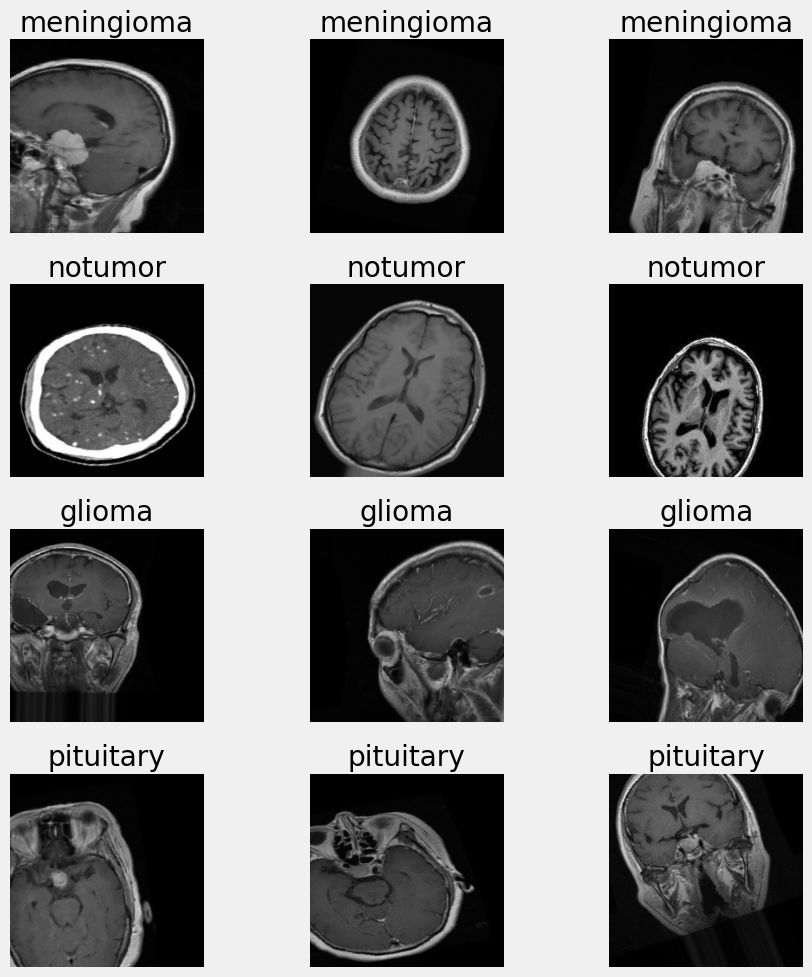

```python
# Function to show images
def show_batch(image_batch, label_batch, class_names, num_examples=3):
    """
    Display a batch of images with their corresponding labels.

    Args:
        image_batch (numpy.ndarray): Batch of images.
        label_batch (numpy.ndarray): Batch of labels.
        class_names (list): List of class names.
        num_examples (int): Number of examples to display per class.

    """
    plt.figure(figsize=(10,10))
    # Find indices for each class
    class_indices = {}
    for i, label in enumerate(label_batch):
        class_idx = np.argmax(label)
        class_name = class_names[class_idx]
        if class_name not in class_indices:
            class_indices[class_name] = []
        if len(class_indices[class_name]) < num_examples:
            class_indices[class_name].append(i)

    # Display images
    plot_idx = 1
    for class_name, indices in class_indices.items():
        for idx in indices:
            plt.subplot(len(class_names), num_examples, plot_idx)
            plt.imshow(image_batch[idx])
            plt.title(class_name)
            plt.axis("off")
            plot_idx += 1
    plt.tight_layout()
    plt.show()

# Get a batch of images and labels from the training generator
image_batch, label_batch = next(train_generator)

# Get class names from the generator
class_names = list(train_generator.class_indices.keys())

# Show examples
show_batch(image_batch, label_batch, class_names, num_examples=3)
```

Each image is stored in JPEG format and has been preprocessed for consistency. The dataset provides a balanced number of samples across classes, enabling both classification research tasks.

## Data balance

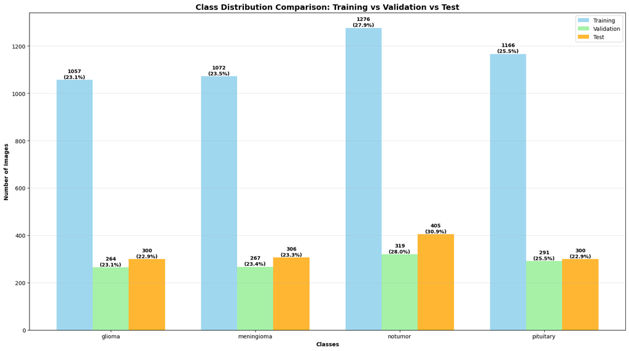

```python
# Check for class balance
# Get class information
num_classes = len(train_generator.class_indices)
class_names = list(train_generator.class_indices.keys())
train_class_counts = np.bincount(train_generator.classes)
val_class_counts = np.bincount(validation_generator.classes)
test_class_counts = np.bincount(test_generator.classes)

# More detailed analysis with percentages
plt.figure(figsize=(16, 9))

x = np.arange(len(class_names))
width = 0.25

# Calculate percentages
train_percentages = (train_class_counts / train_class_counts.sum()) * 100
val_percentages = (val_class_counts / val_class_counts.sum()) * 100
test_percentages = (test_class_counts / test_class_counts.sum()) * 100

# Create bars
bars1 = plt.bar(x - width, train_class_counts, width, label='Training', color='skyblue', alpha=0.8)
bars2 = plt.bar(x, val_class_counts, width, label='Validation', color='lightgreen', alpha=0.8)
bars3 = plt.bar(x + width, test_class_counts, width, label='Test', color='orange', alpha=0.8)

# Add labels and title
plt.xlabel('Classes', fontweight='bold')
plt.ylabel('Number of Images', fontweight='bold')
plt.title('Class Distribution Comparison: Training vs Validation vs Test', fontweight='bold', fontsize=14)
plt.xticks(x, class_names)
plt.legend()

# Add value labels with percentages
for i, (bar1, bar2, bar3) in enumerate(zip(bars1, bars2, bars3)):
    # Training labels
    plt.text(bar1.get_x() + bar1.get_width()/2, bar1.get_height() + 0.5,
             f'{train_class_counts[i]}\n({train_percentages[i]:.1f}%)',
             ha='center', va='bottom', fontsize=9, fontweight='bold')
    # Validation labels
    plt.text(bar2.get_x() + bar2.get_width()/2, bar2.get_height() + 0.5,
             f'{val_class_counts[i]}\n({val_percentages[i]:.1f}%)',
             ha='center', va='bottom', fontsize=9, fontweight='bold')
    # Test labels
    plt.text(bar3.get_x() + bar3.get_width()/2, bar3.get_height() + 0.5,
             f'{test_class_counts[i]}\n({test_percentages[i]:.1f}%)',
             ha='center', va='bottom', fontsize=9, fontweight='bold')

plt.grid(axis='y', alpha=0.3)
plt.tight_layout()
plt.show()
```

## Transfer Learning (EfficientNetV2B0)

EfficientNetV2B0 is a suitable choice for transfer learning in brain tumor classification tasks because it combines computational efficiency with high representational power. Pretrained on the large-scale ImageNet dataset, it provides a rich set of feature representations that can be effectively adapted to medical imaging domains where annotated data is often limited.

```python
## Model definition
def create_model1(num_classes):
    """
    Build a transfer learning model using EfficientNetV2B0 as the feature extractor.

    This function constructs a deep learning model for image classification by leveraging
    EfficientNetV2B0 pretrained on ImageNet as the base model. The base is frozen to act
    as a fixed feature extractor, and a custom classification head is added on top.

    Architecture:
    - Input layer matching the global `IMG_SIZE` (height, width, 3).
    - EfficientNetV2B0 backbone (pretrained, frozen).
    - Flatten layer to convert feature maps into a 1D vector.
    - Dense (1024 units, ReLU) with Dropout(0.25) for regularization.
    - Dense output layer with softmax activation for multi-class classification.

    Args:
        num_classes (int): Number of target classes for classification.

    Returns:
        tensorflow.keras.Model: Compiled Keras model ready for training or fine-tuning.

    Notes:
        - The base model layers are frozen by default (not trainable).
          To enable fine-tuning, set `base_model.trainable = True` after creating the model.
    """

    # Load base model with pretrained weights
    base_model = EfficientNetV2B0(
        include_top=False,
        weights='imagenet',
        input_shape=(*IMG_SIZE, 3))

    # Freeze base model layers
    base_model.trainable = False

    # Create new model on top
    inputs = tf.keras.Input(shape=(*IMG_SIZE, 3))
    x = base_model(inputs, training=False)
    x = Flatten()(x)
    x = Dropout(0.25)(x)
    x = Dense(1024, activation='relu')(x)
    x = Dropout(0.25)(x)

    outputs = Dense(num_classes, activation='softmax', dtype='float32')(x)

    model = Model(inputs, outputs)

    return model
```

```python
# Create model
model1 = create_model1(num_classes)

for layer in model1.layers:
    print(f"{layer.name}: {layer.dtype_policy}")
```

```
Downloading data from https://storage.googleapis.com/tensorflow/keras-applications/efficientnet_v2/efficientnetv2-b0_notop.h5
24274472/24274472 ━━━━━━━━━━━━━━━━━━━━ 0s 0us/step
input_layer_1: <DTypePolicy "float32">
efficientnetv2-b0: <DTypePolicy "float32">
flatten: <DTypePolicy "float32">
dropout: <DTypePolicy "float32">
dense: <DTypePolicy "float32">
dropout_1: <DTypePolicy "float32">
dense_1: <DTypePolicy "float32">
```

```python
model1.summary()
```

```
Model: "functional"
```

```
┏━━━━━━━━━━━━━━━━━━━━━━━━━━━━━━━━━┳━━━━━━━━━━━━━━━━━━━━━━━━┳━━━━━━━━━━━━━━━┓
┃ Layer (type)                    ┃ Output Shape           ┃       Param # ┃
┡━━━━━━━━━━━━━━━━━━━━━━━━━━━━━━━━━╇━━━━━━━━━━━━━━━━━━━━━━━━╇━━━━━━━━━━━━━━━┩
│ input_layer_1 (InputLayer)      │ (None, 224, 224, 3)    │             0 │
├─────────────────────────────────┼────────────────────────┼───────────────┤
│ efficientnetv2-b0 (Functional)  │ (None, 7, 7, 1280)     │     5,919,312 │
├─────────────────────────────────┼────────────────────────┼───────────────┤
│ flatten (Flatten)               │ (None, 62720)          │             0 │
├─────────────────────────────────┼────────────────────────┼───────────────┤
│ dropout (Dropout)               │ (None, 62720)          │             0 │
├─────────────────────────────────┼────────────────────────┼───────────────┤
│ dense (Dense)                   │ (None, 1024)           │    64,226,304 │
├─────────────────────────────────┼────────────────────────┼───────────────┤
│ dropout_1 (Dropout)             │ (None, 1024)           │             0 │
├─────────────────────────────────┼────────────────────────┼───────────────┤
│ dense_1 (Dense)                 │ (None, 4)              │         4,100 │
└─────────────────────────────────┴────────────────────────┴───────────────┘
```

```
 Total params: 70,149,716 (267.60 MB)
```

```
 Trainable params: 64,230,404 (245.02 MB)
```

```
 Non-trainable params: 5,919,312 (22.58 MB)
```

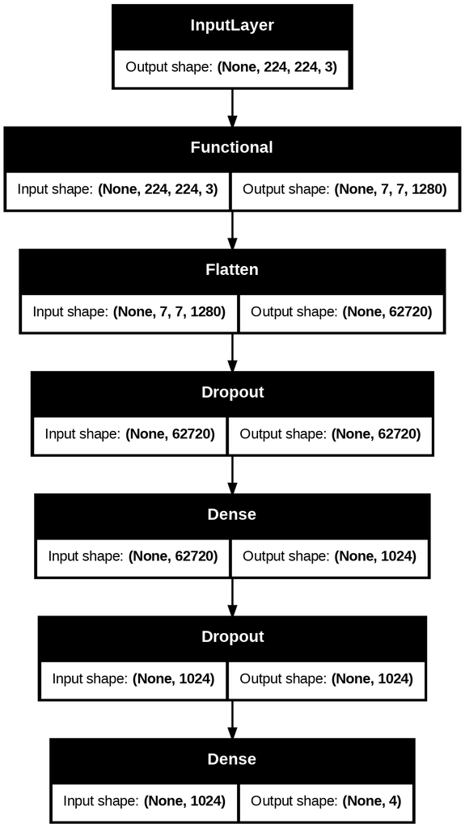

```python
tf.keras.utils.plot_model(model1, show_shapes=True)
```

### Model compilation

```python
# Custom learning rate
initial_learning_rate = 0.001

# Compile the model with accuracy, precision and recall as evaluation metrics
model1.compile(
    optimizer=tf.keras.optimizers.Adamax(learning_rate=initial_learning_rate),
    loss='categorical_crossentropy',
    metrics=['accuracy', Precision(name='precision'), Recall(name='recall')]
)
```

### Model Training

```python
# Callbacks
"""
List of Keras callbacks used to optimize and monitor the training process:

1. ModelCheckpoint:
   - Saves the model to "best_model1.keras".
   - Monitors training accuracy (`monitor="accuracy"`).
   - Keeps only the best model according to maximum accuracy (`mode="max"`).

2. EarlyStopping:
   - Stops training early if no improvement is seen.
   - Uses `patience=4` (waits 4 epochs before stopping).
   - Restores the weights of the best-performing epoch (`restore_best_weights=True`).

3. ReduceLROnPlateau:
   - Reduces the learning rate when a metric has stopped improving.
   - Reduces by a factor of 0.1 after `patience=3` epochs without improvement.
"""
callbacks = [
    tf.keras.callbacks.ModelCheckpoint("best_model1.keras", monitor="accuracy", save_best_only=True, mode="max"),
    tf.keras.callbacks.EarlyStopping(patience=4, restore_best_weights=True),
    tf.keras.callbacks.ReduceLROnPlateau(factor=0.1, patience=3)
]

# Training
history1 = model1.fit(
    train_generator,
    epochs=30,
    validation_data=validation_generator,
    callbacks=callbacks
)
```

```
143/143 ━━━━━━━━━━━━━━━━━━━━ 174s 998ms/step - accuracy: 0.2575 - loss: 16.5933 - precision: 0.2515 - recall: 0.2255 - val_accuracy: 0.2568 - val_loss: 1.3826 - val_precision: 0.0000e+00 - val_recall: 0.0000e+00 - learning_rate: 0.0010
143/143 ━━━━━━━━━━━━━━━━━━━━ 85s 594ms/step - accuracy: 0.2864 - loss: 1.3857 - precision: 0.9514 - recall: 8.6621e-04 - val_accuracy: 0.2796 - val_loss: 1.3696 - val_precision: 0.0000e+00 - val_recall: 0.0000e+00 - learning_rate: 0.0010
143/143 ━━━━━━━━━━━━━━━━━━━━ 82s 573ms/step - accuracy: 0.2969 - loss: 1.3679 - precision: 0.1624 - recall: 5.4035e-04 - val_accuracy: 0.4067 - val_loss: 1.3552 - val_precision: 0.0000e+00 - val_recall: 0.0000e+00 - learning_rate: 0.0010
143/143 ━━━━━━━━━━━━━━━━━━━━ 72s 505ms/step - accuracy: 0.3090 - loss: 1.3554 - precision: 0.6069 - recall: 0.0094 - val_accuracy: 0.4075 - val_loss: 1.3567 - val_precision: 0.0000e+00 - val_recall: 0.0000e+00 - learning_rate: 0.0010
143/143 ━━━━━━━━━━━━━━━━━━━━ 86s 605ms/step - accuracy: 0.3257 - loss: 1.3525 - precision: 0.5524 - recall: 0.0087 - val_accuracy: 0.2796 - val_loss: 1.3545 - val_precision: 1.0000 - val_recall: 0.0018 - learning_rate: 0.0010
143/143 ━━━━━━━━━━━━━━━━━━━━ 72s 505ms/step - accuracy: 0.3094 - loss: 1.3560 - precision: 0.5993 - recall: 0.0144 - val_accuracy: 0.3129 - val_loss: 1.3663 - val_precision: 1.0000 - val_recall: 8.7642e-04 - learning_rate: 0.0010
143/143 ━━━━━━━━━━━━━━━━━━━━ 80s 560ms/step - accuracy: 0.3295 - loss: 1.3476 - precision: 0.6812 - recall: 0.0278 - val_accuracy: 0.4049 - val_loss: 1.3251 - val_precision: 0.7143 - val_recall: 0.0088 - learning_rate: 0.0010
143/143 ━━━━━━━━━━━━━━━━━━━━ 89s 610ms/step - accuracy: 0.3264 - loss: 1.3307 - precision: 0.7356 - recall: 0.0447 - val_accuracy: 0.3024 - val_loss: 1.3100 - val_precision: 0.7206 - val_recall: 0.0429 - learning_rate: 0.0010
143/143 ━━━━━━━━━━━━━━━━━━━━ 124s 873ms/step - accuracy: 0.3395 - loss: 1.3276 - precision: 0.7012 - recall: 0.0520 - val_accuracy: 0.3427 - val_loss: 1.3439 - val_precision: 0.6471 - val_recall: 0.0096 - learning_rate: 0.0010
143/143 ━━━━━━━━━━━━━━━━━━━━ 100s 703ms/step - accuracy: 0.3493 - loss: 1.3205 - precision: 0.7183 - recall: 0.0566 - val_accuracy: 0.4145 - val_loss: 1.3311 - val_precision: 0.6818 - val_recall: 0.0131 - learning_rate: 0.0010
143/143 ━━━━━━━━━━━━━━━━━━━━ 121s 848ms/step - accuracy: 0.3558 - loss: 1.3181 - precision: 0.7010 - recall: 0.0581 - val_accuracy: 0.4242 - val_loss: 1.3227 - val_precision: 0.6429 - val_recall: 0.0079 - learning_rate: 0.0010
143/143 ━━━━━━━━━━━━━━━━━━━━ 91s 637ms/step - accuracy: 0.3505 - loss: 1.3213 - precision: 0.7537 - recall: 0.0403 - val_accuracy: 0.4443 - val_loss: 1.2965 - val_precision: 0.7042 - val_recall: 0.0438 - learning_rate: 1.0000e-04
143/143 ━━━━━━━━━━━━━━━━━━━━ 101s 711ms/step - accuracy: 0.3614 - loss: 1.3081 - precision: 0.7357 - recall: 0.0697 - val_accuracy: 0.4347 - val_loss: 1.3004 - val_precision: 0.6842 - val_recall: 0.0456 - learning_rate: 1.0000e-04
143/143 ━━━━━━━━━━━━━━━━━━━━ 94s 660ms/step - accuracy: 0.3570 - loss: 1.3090 - precision: 0.7153 - recall: 0.0660 - val_accuracy: 0.4163 - val_loss: 1.3096 - val_precision: 0.7414 - val_recall: 0.0377 - learning_rate: 1.0000e-04
143/143 ━━━━━━━━━━━━━━━━━━━━ 89s 622ms/step - accuracy: 0.3702 - loss: 1.3022 - precision: 0.7372 - recall: 0.0735 - val_accuracy: 0.4522 - val_loss: 1.3067 - val_precision: 0.6818 - val_recall: 0.0394 - learning_rate: 1.0000e-04
143/143 ━━━━━━━━━━━━━━━━━━━━ 73s 511ms/step - accuracy: 0.3499 - loss: 1.3067 - precision: 0.7006 - recall: 0.0678 - val_accuracy: 0.4496 - val_loss: 1.2997 - val_precision: 0.7606 - val_recall: 0.0473 - learning_rate: 1.0000e-05
```

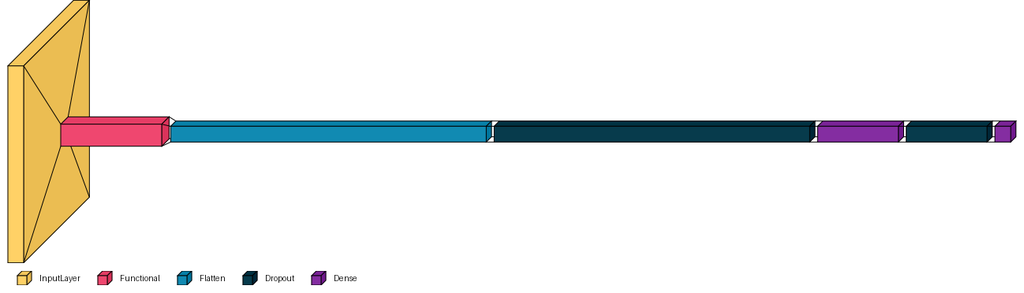

```python
# Visualize layer model
layered_view(model1, legend=True, max_xy=250)
```

### Model Evaluation

```python
def model_evaluation(model, train_gen, test_gen):
  """
  Evaluate a trained Keras model on training and testing datasets.

  This function computes evaluation metrics (loss, accuracy, precision, recall)
  for both training and testing sets, prints the results in a readable format,
  and returns the key metrics for the test set.

  Args:
      model (tf.keras.Model): Trained Keras model to be evaluated.
      train_gen (tf.keras.utils.Sequence or tf.data.Dataset):
          Data generator or dataset for training data.
      test_gen (tf.keras.utils.Sequence or tf.data.Dataset):
          Data generator or dataset for testing data.

  Returns:
      dict: A dictionary containing rounded evaluation metrics for the test set:
          - 'accuracy' (float): Model accuracy on the test set.
          - 'precision' (float): Model precision on the test set.
          - 'recall' (float): Model recall on the test set.

  Notes:
      - Assumes that `model.compile()` was called with metrics including
        accuracy, precision, and recall (in that order).
      - Prints both training and testing loss/accuracy to the console.
  """
  train_score = model.evaluate(train_gen, verbose=1)
  test_score = model.evaluate(test_gen, verbose=1)

  print(f"Train Loss: {train_score[0]:.4f}")
  print(f"Train Accuracy: {train_score[1]*100:.2f}%")
  print('-' * 20)
  print(f"Test Loss: {test_score[0]:.4f}")
  print(f"Test Accuracy: {test_score[1]*100:.2f}%")
  return {'accuracy':round(test_score[1],2),'precision':round(test_score[2],2),'recall':round(test_score[3],2),}
```

```python
test1_metrics = model_evaluation(model1, train_generator, test_generator)
```

```
143/143 ━━━━━━━━━━━━━━━━━━━━ 61s 428ms/step - accuracy: 0.4439 - loss: 1.2587 - precision: 0.9677 - recall: 0.0710
41/41 ━━━━━━━━━━━━━━━━━━━━ 18s 453ms/step - accuracy: 0.4108 - loss: 1.3279 - precision: 0.3407 - recall: 0.0580
Train Loss: 1.2619
Train Accuracy: 43.43%
--------------------
Test Loss: 1.2786
Test Accuracy: 39.89%
```

```python
test1_metrics
```

```
{'accuracy': 0.4, 'precision': 0.72, 'recall': 0.11}
```

```python
def plot_history(hist):
  """
  Plot training and validation metrics from a Keras History object.

  This function visualizes the progression of loss, accuracy, precision,
  and recall across training epochs for both training and validation sets.
  It also highlights the best epoch (based on validation performance) for
  each metric.

  Args:
      hist (tf.keras.callbacks.History):
          History object returned by `model.fit()`, containing training
          and validation metrics across epochs.

  Plots:
      - Training vs Validation Loss (with best epoch marked).
      - Training vs Validation Accuracy (with best epoch marked).
      - Training vs Validation Precision (with best epoch marked).
      - Training vs Validation Recall (with best epoch marked).
  """
  # Get evaluation metrics during training
  tr_acc = hist.history['accuracy']
  tr_loss = hist.history['loss']
  tr_per = hist.history['precision']
  tr_recall = hist.history['recall']
  val_acc = hist.history['val_accuracy']
  val_loss = hist.history['val_loss']
  val_per = hist.history['val_precision']
  val_recall = hist.history['val_recall']

  # Get best results
  index_loss = np.argmin(val_loss)
  val_lowest = val_loss[index_loss]
  index_acc = np.argmax(val_acc)
  acc_highest = val_acc[index_acc]
  index_precision = np.argmax(val_per)
  per_highest = val_per[index_precision]
  index_recall = np.argmax(val_recall)
  recall_highest = val_recall[index_recall]

  # Get the epoch with the best score
  Epochs = [i + 1 for i in range(len(tr_acc))]
  loss_label = f'Best epoch = {str(index_loss + 1)}'
  acc_label = f'Best epoch = {str(index_acc + 1)}'
  per_label = f'Best epoch = {str(index_precision + 1)}'
  recall_label = f'Best epoch = {str(index_recall + 1)}'

  # Set main canvas
  plt.figure(figsize=(20, 12))
  plt.style.use('fivethirtyeight')

  # Plot Loss
  plt.subplot(2, 2, 1)
  plt.plot(Epochs, tr_loss, 'r', label='Training loss')
  plt.plot(Epochs, val_loss, 'g', label='Validation loss')
  plt.scatter(index_loss + 1, val_lowest, s=150, c='blue', label=loss_label)
  plt.title('Training and Validation Loss')
  plt.xlabel('Epochs')
  plt.ylabel('Loss')
  plt.legend()
  plt.grid(True)

  # Plot Accuracy
  plt.subplot(2, 2, 2)
  plt.plot(Epochs, tr_acc, 'r', label='Training Accuracy')
  plt.plot(Epochs, val_acc, 'g', label='Validation Accuracy')
  plt.scatter(index_acc + 1, acc_highest, s=150, c='blue', label=acc_label)
  plt.title('Training and Validation Accuracy')
  plt.xlabel('Epochs')
  plt.ylabel('Accuracy')
  plt.legend()
  plt.grid(True)

  # Plot Precision
  plt.subplot(2, 2, 3)
  plt.plot(Epochs, tr_per, 'r', label='Precision')
  plt.plot(Epochs, val_per, 'g', label='Validation Precision')
  plt.scatter(index_precision + 1, per_highest, s=150, c='blue', label=per_label)
  plt.title('Precision and Validation Precision')
  plt.xlabel('Epochs')
  plt.ylabel('Precision')
  plt.legend()
  plt.grid(True)

  # Plot Recall
  plt.subplot(2, 2, 4)
  plt.plot(Epochs, tr_recall, 'r', label='Recall')
  plt.plot(Epochs, val_recall, 'g', label='Validation Recall')
  plt.scatter(index_recall + 1, recall_highest, s=150, c='blue', label=recall_label)
  plt.title('Recall and Validation Recall')
  plt.xlabel('Epochs')
  plt.ylabel('Recall')
  plt.legend()
  plt.grid(True)

  plt.suptitle('Model Training Metrics Over Epochs', fontsize=16)
  plt.show()
```

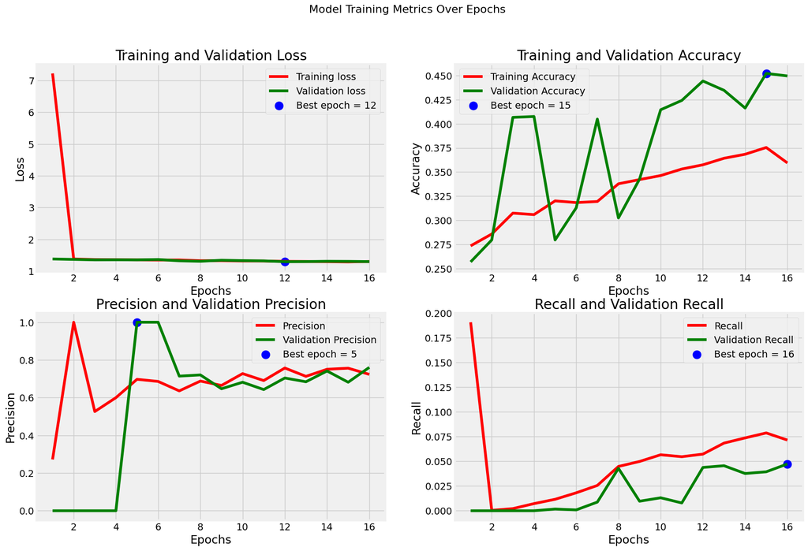

```python
plot_history(history1)
```

```python
def plot_confusion_matrix(tst_gen, y_pred):
  """
  Plot a confusion matrix for classification results.

  This function generates a heatmap visualization of the confusion matrix
  comparing true labels from a test generator with predicted labels.

  Args:
      tst_gen (tf.keras.utils.Sequence or DirectoryIterator):
          Test data generator containing ground truth labels (`classes`)
          and class indices (`class_indices`).
      y_pred (array-like of shape (n_samples,)):
          Predicted class labels for the test set.

  Plots:
      - Confusion matrix as a seaborn heatmap with:
          * Rows = True labels.
          * Columns = Predicted labels.
          * Annotated cell counts.
          * Class names as tick labels.

  Notes:
      - Assumes `y_pred` contains class indices (not probabilities).
      - Uses matplotlib and seaborn for visualization.
  """
  # Get confusion matrix
  cm = confusion_matrix(tst_gen.classes, y_pred)
  # Plot confusion matrix
  class_dict = tst_gen.class_indices
  labels = list(class_dict.keys())
  plt.figure(figsize=(10,8))
  sns.heatmap(cm, annot=True, fmt='d', cmap='Blues', xticklabels=labels, yticklabels=labels)
  plt.xlabel('Predicted Label')
  plt.ylabel('Truth Label')
  plt.show()
```

```
41/41 ━━━━━━━━━━━━━━━━━━━━ 15s 236ms/step
```

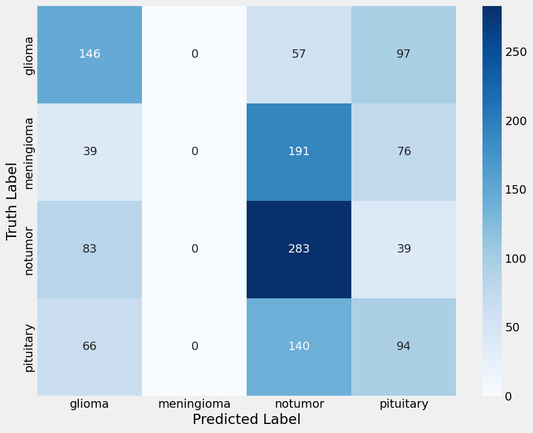

```python
# Test model with new data and plot confusion matrix
preds = model1.predict(test_generator)
y_pred = np.argmax(preds, axis=1)
plot_confusion_matrix(test_generator, y_pred)
```

## Transfer learning (Xception)

The Xception architecture excels due to its depthwise separable convolutions, which enable efficient learning of spatial and channel-wise features. Pretrained on ImageNet, Xception provides rich feature representations that can be repurposed for medical imaging tasks, particularly where data is limited.

```python
def create_model2(num_classes, IMG_SIZE=(224, 224)):
    """
    Build a transfer learning model using Xception as the feature extractor
    with an additional convolutional layer for Grad-CAM interpretability.

    Architecture:
    - Input layer matching the specified IMG_SIZE (height, width, 3).
    - Xception backbone (pretrained, frozen, without top layers).
    - Convolutional layer (3x3, 512 filters, ReLU, same padding) for Grad-CAM.
    - BatchNormalization for training stability.
    - GlobalAveragePooling2D to reduce feature maps to a vector.
    - Dense layer with 128 units and ReLU activation, with Dropout for regularization.
    - Dense output layer with `num_classes` units and softmax activation, explicitly set to float32.

    Args:
        num_classes (int): Number of target classes for classification.
        IMG_SIZE (tuple, optional): Input image size as (height, width). Defaults to (224, 224).

    Returns:
        tf.keras.Model: Compiled Keras model ready for training or fine-tuning.

    Notes:
        - The base Xception layers are frozen by default (`trainable=False`), but can be
          unfrozen for fine-tuning.
        - The added convolutional layer is designed to support Grad-CAM visualizations,
          highlighting regions important for model predictions.
        - The output layer is set to float32 to ensure numerical stability during training.
    """
    # define input
    inputs = Input(shape=(*IMG_SIZE, 3))

    # build the backbone directly
    x = Xception(
        include_top=False,
        weights='imagenet',
        input_tensor=inputs,
        pooling=None
    )(inputs)

    # Freeze the Xception base model layers
    x.trainable = False

    # Convolutional layer after the base model for Grad-CAM
    x = Conv2D(512, (3, 3), activation='relu', padding='same', name='gradcam_conv')(x)
    x = BatchNormalization()(x)

    # Dense layers for classification
    x = GlobalAveragePooling2D()(x)
    x = Dropout(0.3)(x)
    x = Dense(128, activation='relu')(x)
    x = Dropout(0.2)(x)
    outputs = Dense(num_classes, activation='softmax', dtype='float32')(x)

    model = Model(inputs, outputs)

    return model
```

```python
# Create model
model2 = create_model2(num_classes)
```

```
Downloading data from https://storage.googleapis.com/tensorflow/keras-applications/xception/xception_weights_tf_dim_ordering_tf_kernels_notop.h5
83683744/83683744 ━━━━━━━━━━━━━━━━━━━━ 0s 0us/step
```

```python
model2.summary()
```

```
Model: "functional_1"
```

```
┏━━━━━━━━━━━━━━━━━━━━━━━━━━━━━━━━━┳━━━━━━━━━━━━━━━━━━━━━━━━┳━━━━━━━━━━━━━━━┓
┃ Layer (type)                    ┃ Output Shape           ┃       Param # ┃
┡━━━━━━━━━━━━━━━━━━━━━━━━━━━━━━━━━╇━━━━━━━━━━━━━━━━━━━━━━━━╇━━━━━━━━━━━━━━━┩
│ input_layer_2 (InputLayer)      │ (None, 224, 224, 3)    │             0 │
├─────────────────────────────────┼────────────────────────┼───────────────┤
│ xception (Functional)           │ (None, 7, 7, 2048)     │    20,861,480 │
├─────────────────────────────────┼────────────────────────┼───────────────┤
│ gradcam_conv (Conv2D)           │ (None, 7, 7, 512)      │     9,437,696 │
├─────────────────────────────────┼────────────────────────┼───────────────┤
│ batch_normalization_4           │ (None, 7, 7, 512)      │         2,048 │
│ (BatchNormalization)            │                        │               │
├─────────────────────────────────┼────────────────────────┼───────────────┤
│ global_average_pooling2d        │ (None, 512)            │             0 │
│ (GlobalAveragePooling2D)        │                        │               │
├─────────────────────────────────┼────────────────────────┼───────────────┤
│ dropout_2 (Dropout)             │ (None, 512)            │             0 │
├─────────────────────────────────┼────────────────────────┼───────────────┤
│ dense_2 (Dense)                 │ (None, 128)            │        65,664 │
├─────────────────────────────────┼────────────────────────┼───────────────┤
│ dropout_3 (Dropout)             │ (None, 128)            │             0 │
├─────────────────────────────────┼────────────────────────┼───────────────┤
│ dense_3 (Dense)                 │ (None, 4)              │           516 │
└─────────────────────────────────┴────────────────────────┴───────────────┘
```

```
 Total params: 30,367,404 (115.84 MB)
```

```
 Trainable params: 30,311,852 (115.63 MB)
```

```
 Non-trainable params: 55,552 (217.00 KB)
```

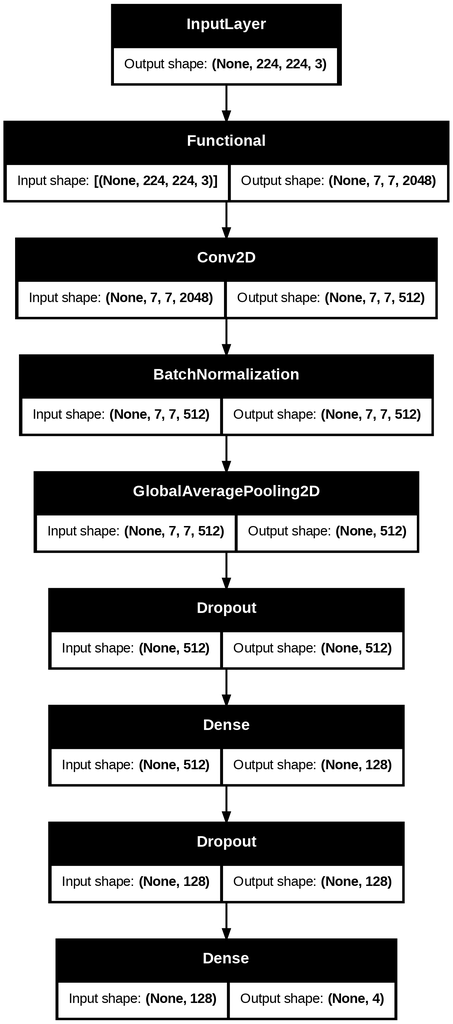

```python
tf.keras.utils.plot_model(model2, show_shapes=True)
```

### Model Compilation

```python
# Custom learning rate (often helpful with mixed precision)
initial_learning_rate = 0.001

model2.compile(
    optimizer=tf.keras.optimizers.Adamax(learning_rate=initial_learning_rate),
    loss='categorical_crossentropy',
    metrics=['accuracy', Precision(name='precision'), Recall(name='recall')]
)
```

### Model Training

```python
# Callbacks
callbacks = [
    tf.keras.callbacks.ModelCheckpoint("best_model2.keras", monitor="accuracy", save_best_only=True, mode="max"),
    tf.keras.callbacks.EarlyStopping(patience=3, restore_best_weights=True),
    tf.keras.callbacks.ReduceLROnPlateau(factor=0.1, patience=3)
]

# Training
history2 = model2.fit(
    train_generator,
    epochs=10,
    validation_data=validation_generator,
    callbacks=callbacks
)
```

```
143/143 ━━━━━━━━━━━━━━━━━━━━ 277s 1s/step - accuracy: 0.8294 - loss: 0.4510 - precision: 0.8663 - recall: 0.7894 - val_accuracy: 0.8501 - val_loss: 0.4073 - val_precision: 0.8650 - val_recall: 0.8422 - learning_rate: 0.0010
143/143 ━━━━━━━━━━━━━━━━━━━━ 110s 767ms/step - accuracy: 0.9622 - loss: 0.1078 - precision: 0.9651 - recall: 0.9604 - val_accuracy: 0.8405 - val_loss: 0.5250 - val_precision: 0.8477 - val_recall: 0.8344 - learning_rate: 0.0010
143/143 ━━━━━━━━━━━━━━━━━━━━ 108s 755ms/step - accuracy: 0.9736 - loss: 0.0916 - precision: 0.9745 - recall: 0.9723 - val_accuracy: 0.9404 - val_loss: 0.2041 - val_precision: 0.9477 - val_recall: 0.9378 - learning_rate: 0.0010
143/143 ━━━━━━━━━━━━━━━━━━━━ 111s 775ms/step - accuracy: 0.9824 - loss: 0.0577 - precision: 0.9833 - recall: 0.9798 - val_accuracy: 0.9571 - val_loss: 0.1969 - val_precision: 0.9595 - val_recall: 0.9553 - learning_rate: 0.0010
143/143 ━━━━━━━━━━━━━━━━━━━━ 99s 688ms/step - accuracy: 0.9816 - loss: 0.0507 - precision: 0.9835 - recall: 0.9814 - val_accuracy: 0.9544 - val_loss: 0.1710 - val_precision: 0.9593 - val_recall: 0.9509 - learning_rate: 0.0010
143/143 ━━━━━━━━━━━━━━━━━━━━ 135s 943ms/step - accuracy: 0.9887 - loss: 0.0398 - precision: 0.9896 - recall: 0.9879 - val_accuracy: 0.9492 - val_loss: 0.1855 - val_precision: 0.9515 - val_recall: 0.9448 - learning_rate: 0.0010
143/143 ━━━━━━━━━━━━━━━━━━━━ 111s 773ms/step - accuracy: 0.9899 - loss: 0.0314 - precision: 0.9909 - recall: 0.9891 - val_accuracy: 0.9632 - val_loss: 0.1578 - val_precision: 0.9640 - val_recall: 0.9623 - learning_rate: 0.0010
143/143 ━━━━━━━━━━━━━━━━━━━━ 98s 683ms/step - accuracy: 0.9867 - loss: 0.0431 - precision: 0.9870 - recall: 0.9856 - val_accuracy: 0.9711 - val_loss: 0.1165 - val_precision: 0.9719 - val_recall: 0.9702 - learning_rate: 0.0010
143/143 ━━━━━━━━━━━━━━━━━━━━ 113s 790ms/step - accuracy: 0.9925 - loss: 0.0181 - precision: 0.9936 - recall: 0.9925 - val_accuracy: 0.9614 - val_loss: 0.1526 - val_precision: 0.9665 - val_recall: 0.9614 - learning_rate: 0.0010
143/143 ━━━━━━━━━━━━━━━━━━━━ 98s 687ms/step - accuracy: 0.9951 - loss: 0.0189 - precision: 0.9953 - recall: 0.9946 - val_accuracy: 0.9544 - val_loss: 0.1591 - val_precision: 0.9560 - val_recall: 0.9527 - learning_rate: 0.0010
```

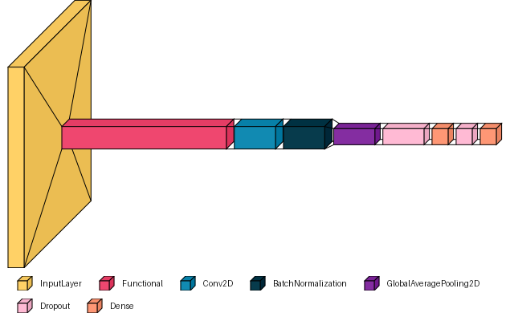

```python
# Visualize layer model
layered_view(model2, legend=True, max_xy=250)
```

### Model Evaluation

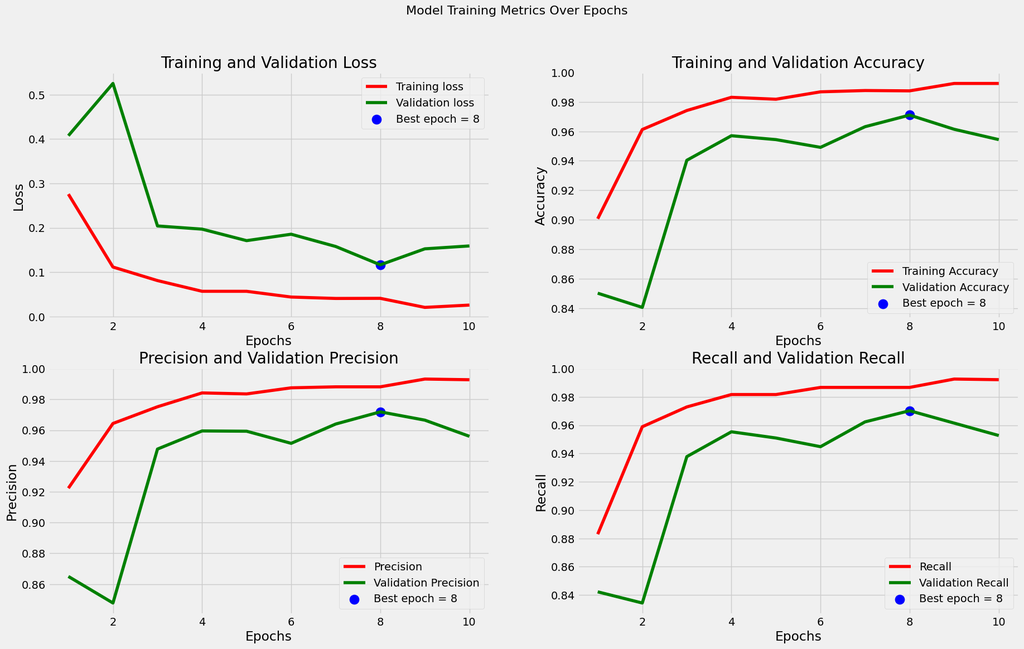

```python
plot_history(history2)
```

Training metrics shows that the bes epoch is the 8th

```python
test2_metrics = model_evaluation(model2, train_generator, test_generator)
```

```
143/143 ━━━━━━━━━━━━━━━━━━━━ 67s 465ms/step - accuracy: 0.9952 - loss: 0.0101 - precision: 0.9952 - recall: 0.9952
41/41 ━━━━━━━━━━━━━━━━━━━━ 23s 560ms/step - accuracy: 0.9728 - loss: 0.1021 - precision: 0.9728 - recall: 0.9728
Train Loss: 0.0097
Train Accuracy: 99.58%
--------------------
Test Loss: 0.0604
Test Accuracy: 98.40%
```

```python
test2_metrics
```

```
{'accuracy': 0.98, 'precision': 0.98, 'recall': 0.98}
```

```
41/41 ━━━━━━━━━━━━━━━━━━━━ 14s 239ms/step
```

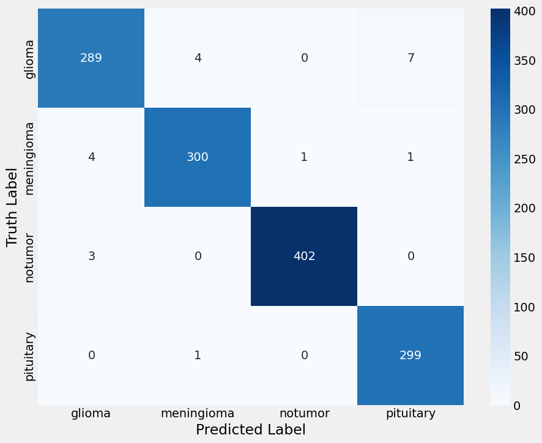

```python
preds = model2.predict(test_generator)
y_pred = np.argmax(preds, axis=1)
plot_confusion_matrix(test_generator, y_pred)
```

## Build CNN from Scratch

A custom CNN built from scratch, allows full control over the feature extraction process specifically tailored to MRI images. The use of multiple convolutional blocks with increasing filter sizes enables hierarchical feature learning, capturing both low-level patterns (edges, textures) and high-level structures (tumor shapes and regions).

```python
## Model definition
def create_model3(num_classes):
    """
    Build a convolutional neural network (CNN) model from scratch for image classification.

    Architecture:
    - Input layer matching the global IMG_SIZE (height, width, 3).
    - Initial Conv2D layer (64 filters, 7x7 kernel, ReLU) with BatchNormalization and MaxPooling.
    - Three convolutional blocks with increasing filters (128, 256, 512), each containing:
        * Conv2D layer (3x3, ReLU, same padding)
        * BatchNormalization
        * MaxPooling2D
        * Dropout(0.25)
    - GlobalAveragePooling2D to reduce feature maps to a vector.
    - Fully connected layers with decreasing units (1024 → 512 → 128), each with:
        * ReLU activation
        * L2 kernel regularization
        * BatchNormalization
        * Dropout (0.5 → 0.3 → 0.2)
    - Dense output layer with softmax activation (float32) for classification.

    Args:
        num_classes (int): Number of target classes for classification.

    Returns:
        tf.keras.Model: Keras model instance ready for compilation and training.
    """
    # Create new model from scratch
    inputs = tf.keras.Input(shape=(*IMG_SIZE, 3))
    x = Conv2D(64, (7,7), activation='relu', padding='same')(inputs)
    x = BatchNormalization()(x)
    x = MaxPooling2D((2,2))(x)

    # Multiple convulutional blocks with increasing filters
    filters = [128, 256, 512]
    for f in filters:
        x = Conv2D(f, (3,3), activation='relu', padding='same')(x)
        x = BatchNormalization()(x)
        x = MaxPooling2D((2,2))(x)
        x = Dropout(0.25)(x)

    # Global average pooling instead of flatten
    x = GlobalAveragePooling2D()(x)

    # Fully connected layers
    x = Dense(1024, activation='relu', kernel_regularizer=tf.keras.regularizers.l2(0.001))(x)
    x = BatchNormalization()(x)
    x = Dropout(0.5)(x)

    x = Dense(512, activation='relu', kernel_regularizer=tf.keras.regularizers.l2(0.001))(x)
    x = BatchNormalization()(x)
    x = Dropout(0.3)(x)

    x = Dense(128, activation='relu', kernel_regularizer=tf.keras.regularizers.l2(0.001))(x)
    x = BatchNormalization()(x)
    x = Dropout(0.2)(x)


    # Ensure output layer is float32 for stability
    outputs = Dense(num_classes, activation='softmax', dtype='float32')(x)

    model = Model(inputs, outputs)

    return model
```

```python
# Create model
model3 = create_model3(num_classes)

for layer in model3.layers:
    print(f"{layer.name}: {layer.dtype_policy}")
```

```
input_layer_3: <DTypePolicy "float32">
conv2d_4: <DTypePolicy "float32">
batch_normalization_5: <DTypePolicy "float32">
max_pooling2d: <DTypePolicy "float32">
conv2d_5: <DTypePolicy "float32">
batch_normalization_6: <DTypePolicy "float32">
max_pooling2d_1: <DTypePolicy "float32">
dropout_4: <DTypePolicy "float32">
conv2d_6: <DTypePolicy "float32">
batch_normalization_7: <DTypePolicy "float32">
max_pooling2d_2: <DTypePolicy "float32">
dropout_5: <DTypePolicy "float32">
conv2d_7: <DTypePolicy "float32">
batch_normalization_8: <DTypePolicy "float32">
max_pooling2d_3: <DTypePolicy "float32">
dropout_6: <DTypePolicy "float32">
global_average_pooling2d_1: <DTypePolicy "float32">
dense_4: <DTypePolicy "float32">
batch_normalization_9: <DTypePolicy "float32">
dropout_7: <DTypePolicy "float32">
dense_5: <DTypePolicy "float32">
batch_normalization_10: <DTypePolicy "float32">
dropout_8: <DTypePolicy "float32">
dense_6: <DTypePolicy "float32">
batch_normalization_11: <DTypePolicy "float32">
dropout_9: <DTypePolicy "float32">
dense_7: <DTypePolicy "float32">
```

```python
model3.summary()
```

```
Model: "functional_2"
```

```
┏━━━━━━━━━━━━━━━━━━━━━━━━━━━━━━━━━┳━━━━━━━━━━━━━━━━━━━━━━━━┳━━━━━━━━━━━━━━━┓
┃ Layer (type)                    ┃ Output Shape           ┃       Param # ┃
┡━━━━━━━━━━━━━━━━━━━━━━━━━━━━━━━━━╇━━━━━━━━━━━━━━━━━━━━━━━━╇━━━━━━━━━━━━━━━┩
│ input_layer_3 (InputLayer)      │ (None, 224, 224, 3)    │             0 │
├─────────────────────────────────┼────────────────────────┼───────────────┤
│ conv2d_4 (Conv2D)               │ (None, 224, 224, 64)   │         9,472 │
├─────────────────────────────────┼────────────────────────┼───────────────┤
│ batch_normalization_5           │ (None, 224, 224, 64)   │           256 │
│ (BatchNormalization)            │                        │               │
├─────────────────────────────────┼────────────────────────┼───────────────┤
│ max_pooling2d (MaxPooling2D)    │ (None, 112, 112, 64)   │             0 │
├─────────────────────────────────┼────────────────────────┼───────────────┤
│ conv2d_5 (Conv2D)               │ (None, 112, 112, 128)  │        73,856 │
├─────────────────────────────────┼────────────────────────┼───────────────┤
│ batch_normalization_6           │ (None, 112, 112, 128)  │           512 │
│ (BatchNormalization)            │                        │               │
├─────────────────────────────────┼────────────────────────┼───────────────┤
│ max_pooling2d_1 (MaxPooling2D)  │ (None, 56, 56, 128)    │             0 │
├─────────────────────────────────┼────────────────────────┼───────────────┤
│ dropout_4 (Dropout)             │ (None, 56, 56, 128)    │             0 │
├─────────────────────────────────┼────────────────────────┼───────────────┤
│ conv2d_6 (Conv2D)               │ (None, 56, 56, 256)    │       295,168 │
├─────────────────────────────────┼────────────────────────┼───────────────┤
│ batch_normalization_7           │ (None, 56, 56, 256)    │         1,024 │
│ (BatchNormalization)            │                        │               │
├─────────────────────────────────┼────────────────────────┼───────────────┤
│ max_pooling2d_2 (MaxPooling2D)  │ (None, 28, 28, 256)    │             0 │
├─────────────────────────────────┼────────────────────────┼───────────────┤
│ dropout_5 (Dropout)             │ (None, 28, 28, 256)    │             0 │
├─────────────────────────────────┼────────────────────────┼───────────────┤
│ conv2d_7 (Conv2D)               │ (None, 28, 28, 512)    │     1,180,160 │
├─────────────────────────────────┼────────────────────────┼───────────────┤
│ batch_normalization_8           │ (None, 28, 28, 512)    │         2,048 │
│ (BatchNormalization)            │                        │               │
├─────────────────────────────────┼────────────────────────┼───────────────┤
│ max_pooling2d_3 (MaxPooling2D)  │ (None, 14, 14, 512)    │             0 │
├─────────────────────────────────┼────────────────────────┼───────────────┤
│ dropout_6 (Dropout)             │ (None, 14, 14, 512)    │             0 │
├─────────────────────────────────┼────────────────────────┼───────────────┤
│ global_average_pooling2d_1      │ (None, 512)            │             0 │
```

[output cut: 10 more lines]

```
├─────────────────────────────────┼────────────────────────┼───────────────┤
│ batch_normalization_10          │ (None, 512)            │         2,048 │
│ (BatchNormalization)            │                        │               │
├─────────────────────────────────┼────────────────────────┼───────────────┤
│ dropout_8 (Dropout)             │ (None, 512)            │             0 │
├─────────────────────────────────┼────────────────────────┼───────────────┤
│ dense_6 (Dense)                 │ (None, 128)            │        65,664 │
├─────────────────────────────────┼────────────────────────┼───────────────┤
│ batch_normalization_11          │ (None, 128)            │           512 │
│ (BatchNormalization)            │                        │               │
├─────────────────────────────────┼────────────────────────┼───────────────┤
│ dropout_9 (Dropout)             │ (None, 128)            │             0 │
├─────────────────────────────────┼────────────────────────┼───────────────┤
│ dense_7 (Dense)                 │ (None, 4)              │           516 │
└─────────────────────────────────┴────────────────────────┴───────────────┘
```

```
 Total params: 2,685,444 (10.24 MB)
```

```
 Trainable params: 2,680,196 (10.22 MB)
```

```
 Non-trainable params: 5,248 (20.50 KB)
```

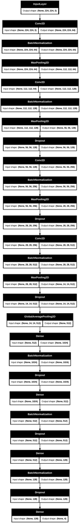

```python
tf.keras.utils.plot_model(model3, show_shapes=True)
```

### Model Compilation

```python
# Custom learning rate (often helpful with mixed precision)
initial_learning_rate = 0.001

model3.compile(
    optimizer=tf.keras.optimizers.Adamax(learning_rate=initial_learning_rate),
    loss='categorical_crossentropy',
    metrics=['accuracy', Precision(name='precision'), Recall(name='recall')]
)
```

### Model Training

```python
# Callbacks
callbacks = [
    tf.keras.callbacks.ModelCheckpoint("best_model3.keras", monitor="accuracy", save_best_only=True, mode="max"),
    tf.keras.callbacks.EarlyStopping(patience=4, restore_best_weights=True),
    tf.keras.callbacks.ReduceLROnPlateau(factor=0.1, patience=3)
]

# Training
history3 = model3.fit(
    train_generator,
    epochs=30,
    validation_data=validation_generator,
    callbacks=callbacks
)
```

```
143/143 ━━━━━━━━━━━━━━━━━━━━ 134s 754ms/step - accuracy: 0.5712 - loss: 2.6985 - precision: 0.6092 - recall: 0.4915 - val_accuracy: 0.2550 - val_loss: 4.1987 - val_precision: 0.2550 - val_recall: 0.2550 - learning_rate: 0.0010
143/143 ━━━━━━━━━━━━━━━━━━━━ 80s 560ms/step - accuracy: 0.6814 - loss: 2.2398 - precision: 0.7285 - recall: 0.6277 - val_accuracy: 0.2550 - val_loss: 8.7323 - val_precision: 0.2550 - val_recall: 0.2550 - learning_rate: 0.0010
143/143 ━━━━━━━━━━━━━━━━━━━━ 78s 547ms/step - accuracy: 0.7208 - loss: 2.1667 - precision: 0.7550 - recall: 0.6819 - val_accuracy: 0.3786 - val_loss: 7.6898 - val_precision: 0.3784 - val_recall: 0.3751 - learning_rate: 0.0010
143/143 ━━━━━━━━━━━━━━━━━━━━ 80s 560ms/step - accuracy: 0.7392 - loss: 2.0681 - precision: 0.7770 - recall: 0.6899 - val_accuracy: 0.4242 - val_loss: 7.3329 - val_precision: 0.4242 - val_recall: 0.4242 - learning_rate: 0.0010
143/143 ━━━━━━━━━━━━━━━━━━━━ 80s 556ms/step - accuracy: 0.7695 - loss: 1.9962 - precision: 0.7995 - recall: 0.7309 - val_accuracy: 0.4312 - val_loss: 7.2592 - val_precision: 0.4316 - val_recall: 0.4312 - learning_rate: 1.0000e-04
```

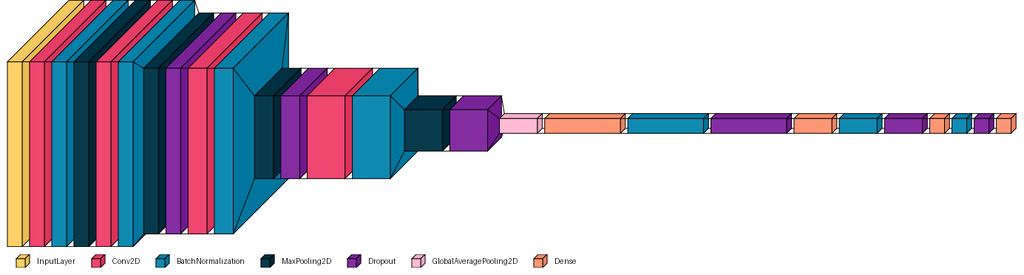

```python
# Visualize layer model
layered_view(model3, legend=True, max_xy=250)
```

### Model Evaluation

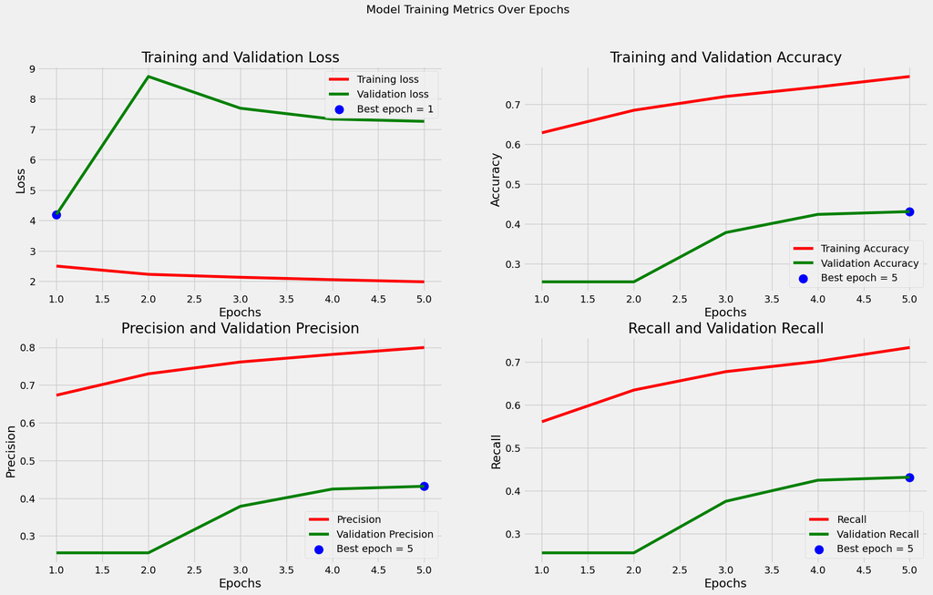

```python
plot_history(history3)
```

```python
test3_metrics = model_evaluation(model3, train_generator, test_generator)
```

```
143/143 ━━━━━━━━━━━━━━━━━━━━ 63s 442ms/step - accuracy: 0.2500 - loss: 4.2202 - precision: 0.2500 - recall: 0.2500
41/41 ━━━━━━━━━━━━━━━━━━━━ 8s 209ms/step - accuracy: 0.0361 - loss: 4.7450 - precision: 0.0361 - recall: 0.0361
Train Loss: 4.1912
Train Accuracy: 25.51%
--------------------
Test Loss: 4.2850
Test Accuracy: 22.88%
```

```python
test3_metrics
```

```
{'accuracy': 0.23, 'precision': 0.23, 'recall': 0.23}
```

```
41/41 ━━━━━━━━━━━━━━━━━━━━ 4s 84ms/step
```

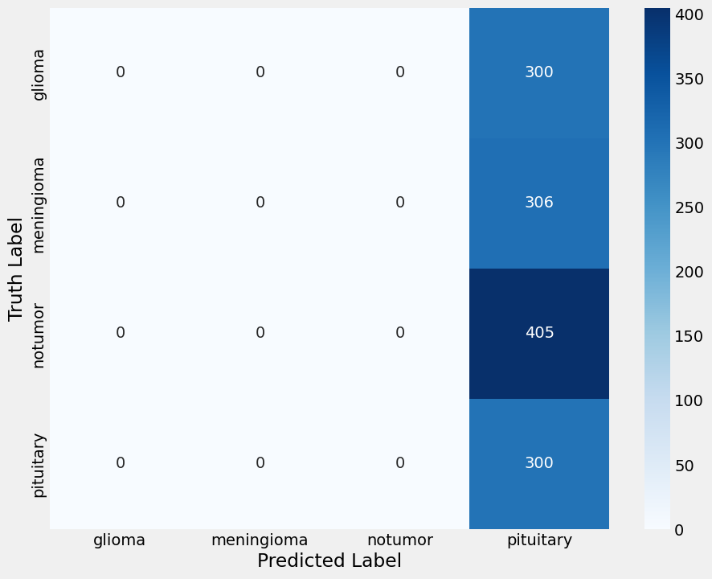

```python
preds = model3.predict(test_generator)
y_pred = np.argmax(preds, axis=1)
plot_confusion_matrix(test_generator, y_pred)
```

## Best model

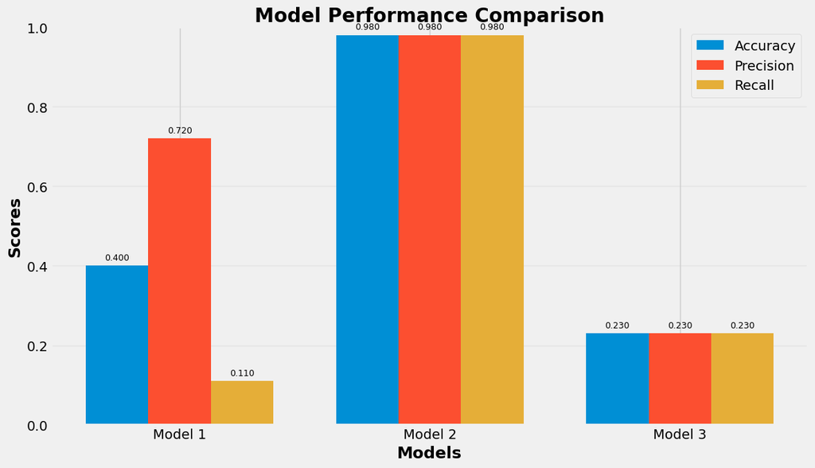

```python
# Show a model metrics comparation
metrics_data = [test1_metrics, test2_metrics, test3_metrics]
model_names = ['Model 1', 'Model 2', 'Model 3']
metric_names = ['accuracy', 'precision', 'recall']

# Create grouped bar plot
plt.figure(figsize=(12, 7))

x = np.arange(len(model_names))
width = 0.25

for i, metric in enumerate(metric_names):
    values = [data[metric] for data in metrics_data]
    plt.bar(x + i * width, values, width, label=metric.capitalize())

plt.xlabel('Models', fontweight='bold')
plt.ylabel('Scores', fontweight='bold')
plt.title('Model Performance Comparison', fontweight='bold')
plt.xticks(x + width, model_names)
plt.legend()
plt.ylim(0, 1)

# Add value labels
for i, model_data in enumerate(metrics_data):
    for j, metric in enumerate(metric_names):
        plt.text(i + j * width, model_data[metric] + 0.01,
                f'{model_data[metric]:.3f}', ha='center', va='bottom', fontsize=9)

plt.grid(axis='y', alpha=0.3)
plt.tight_layout()
plt.show()
```

Fron the 3 experiments the one with the best performance is the Xception architecture.

## Inference with best model

```
1/1 ━━━━━━━━━━━━━━━━━━━━ 5s 5s/step
[[3.0375380e-05 9.9931097e-01 4.5102736e-04 2.0762616e-04]]
```

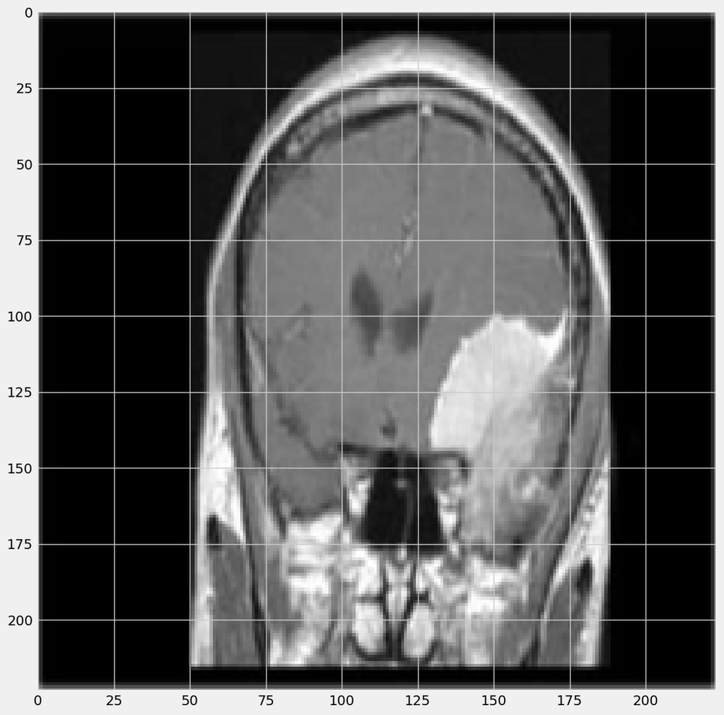

```
Glioma: 0.00%
Meningioma: 99.93%
Pituitary: 0.05%
No Tumor: 0.02%
```

```python
model = tf.keras.models.load_model("best_model2.keras")
class_dict = {'Glioma':0, 'Meningioma':1, 'Pituitary':2, 'No Tumor':3}

def predict(img_path):
    import numpy as np
    import matplotlib.pyplot as plt
    from PIL import Image
    label = list(class_dict.keys())
    plt.figure(figsize=(12, 12))
    img = Image.open(img_path)
    resized_img = img.resize((224, 224))
    img = np.asarray(resized_img)
    img = np.expand_dims(img, axis=0)
    img = img / 255
    predictions = model.predict(img)
    probs = list(predictions[0])
    labels = label
    plt.imshow(resized_img)
    plt.show()
    for i in range(len(labels)):
        print(f"{labels[i]}: {probs[i]*100:.2f}%")

predict('/kaggle/input/brain-tumor-mri-dataset/Testing/meningioma/Te-meTr_0000.jpg')
```